# UMass Amherst Enrollment on Tuitiom

May 1, 2019

## Introduction

- In recent years, UMass have been taking a lot of flack for over-enrolling students
- This has caused many issues, including but not limitted to: Forcing z-rooms and common rooms into triples and quads, Extending service hours for UHS and Dining services, Many students arent able to find rooms, Renovating and upgrading older buildings
- But does this also affect tuition?

## What We Want to Find

- Does enrollment number ofthe University of Massachusetts, Amherst can be used to determine the cost of being a residential student?

## The Data

- The data was found through the The University Analytics and Institutional Research department and concatenated multiple reports to a sinlge simple data frame.

| YEAR | IN-STATE | OUT-STATE | ROOM & BOARD | ENROLLMENT | APPLICATIONS | ACCEPTANCE |
| --- | --- | --- | --- | --- | --- | --- |
| 1984 | 1657 | 4481 | 2398 | 19993 | NA | NA |
| 1985 | 1947 | 4971 | 2244 | 20149 | NA | NA |
| 1986 | 1996 | 5020 | 2401 | 19670 | NA | NA |
| 1987 | 2048 | 5072 | 2584 | 19882 | 27339 | 15229 |
| 1988 | 2518 | 5950 | 2804 | 19826 | 28330 | 14993 |
| 1989 | 2980 | 7371 | 3064 | 18889 | 23287 | 13700 |

## Deflating costs

- Next we must deflate the cost so everything is in 1984 dollars

| IN-STATE-ADJ | OUT-STATE-ADJ | ROOM & BOARD ADJ |
| --- | --- | --- |
| 1657.000 | 4481.000 | 2398.000 |
| 1872.115 | 4779.808 | 2157.692 |
| 1883.019 | 4735.849 | 2265.094 |
| 1878.899 | 4653.211 | 2370.642 |
| 2208.772 | 5219.298 | 2459.649 |
| 2504.202 | 6194.118 | 2574.790 |

## Getting Rates

-Next we remove the effect of time by getting rate of change of costs and enrollment -We also calculate acceptence and admission rate

| ACCRATE | ADMRATE | COST | ENROLLMENTRATE | COSTRATE |
| --- | --- | --- | --- | --- |
| NA | NA | 4140.200 | 0.0000000 | 0.0000000 |
| NA | NA | 4179.808 | 0.0078027 | 0.0095666 |
| NA | NA | 4265.660 | -0.0237729 | 0.0205399 |
| 0.5570431 | 0.4073807 | 4330.275 | 0.0107778 | 0.0151477 |
| 0.5292270 | 0.3778430 | 4778.596 | -0.0028166 | 0.1035318 |
| 0.5883111 | 0.3931387 | 5302.017 | -0.0472612 | 0.1095343 |

## Enrollment & Costs overtime

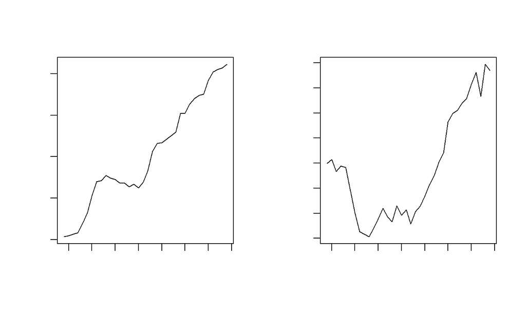

## Admission and acceptance rate over time

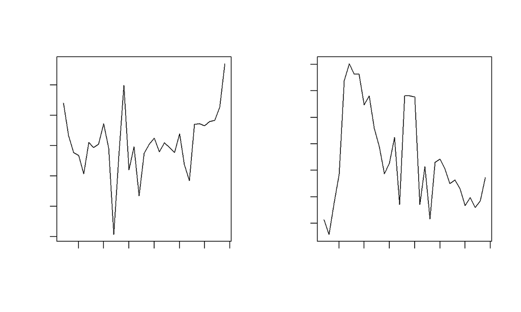

## Rate of change of cost and enrollment over time

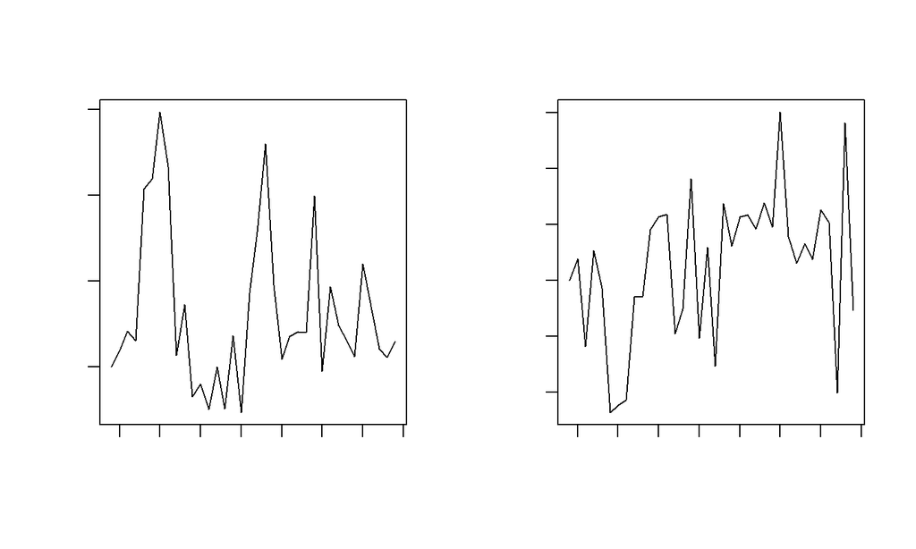

## What happened in 1995?

- We can see in all the graphs a dip in performance.
- This was caused by political & racial tumoil caused by the 1992 ALANA agrreement leading to Goddell sit in 1997
- Since we cannot simply ignore these years, we make it a dummy variable

```r
TURMOIL <- UMASS$YEAR
TURMOIL[1:36] <- 0
TURMOIL[11:15] <- 1
UMASS$TURMOIL <- TURMOIL
```

## Modeling

- We will use a linear regression model and a random forest model using turmoil, enrollment, rate of change of enrollment, acceptance rate, admission rate, and rate of change in enrollment to predict rate of change in costs.
- We train on first 30 years and test on the last 6

## Linear regession

- After running a step function on all the variables, we find that turmoil and enrollment rate of change are the most significant.
- COSTRATE = .052595 -(.062254)TURMOIL -(.838094)ENROLLMENTRATE

  |  | Estimate S | td. Error | t value | Pr(>\|t\|) |
  | --- | --- | --- | --- | --- |
  | (Intercept) | 0.0525952 | 0.0085977 | 6.117337 | 0.0000026 |
  | ENROLLMENTRATE | -0.8380942 | 0.2984705 | -2.807963 | 0.0097471 |
  | TURMOIL | -0.0622536 | 0.0197196 | -3.156935 | 0.0042619 |

## Predicting with linear model

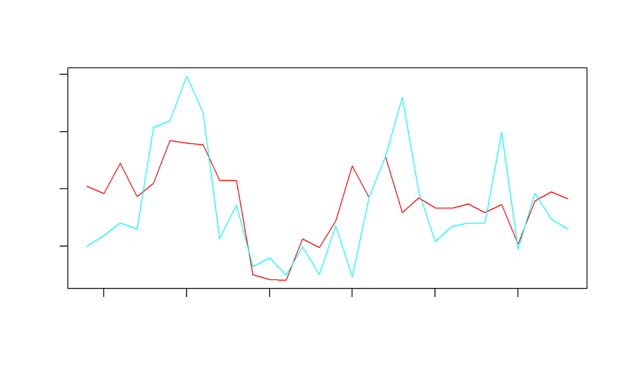

## Residuals

- RMSE = 3.86%
- Total error = 14%

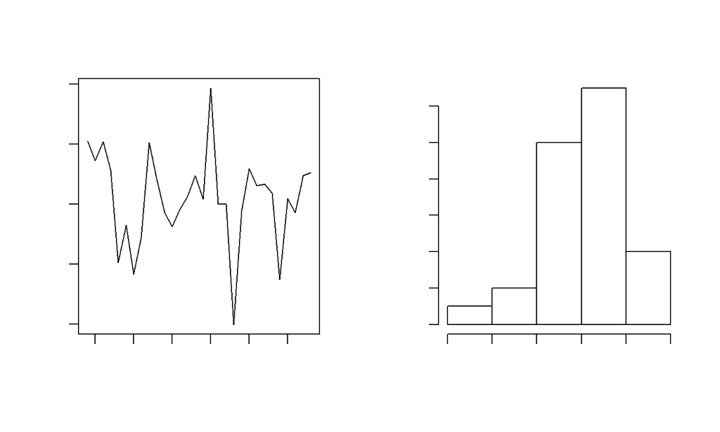

## Random Forest

-Using 4 splits, 500 trees and seed set to 1234

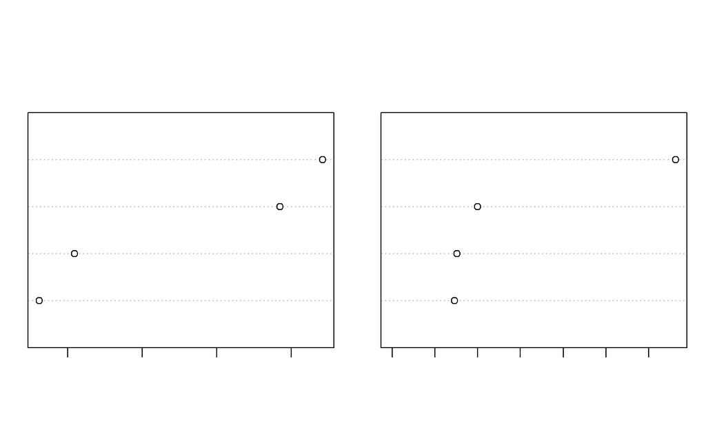

## Predicting with Random Forest

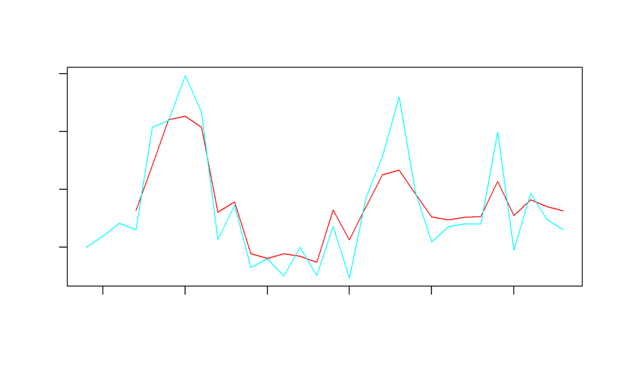

## Residuals

- RMSE = 2.2%
- Total Error = 2.5%

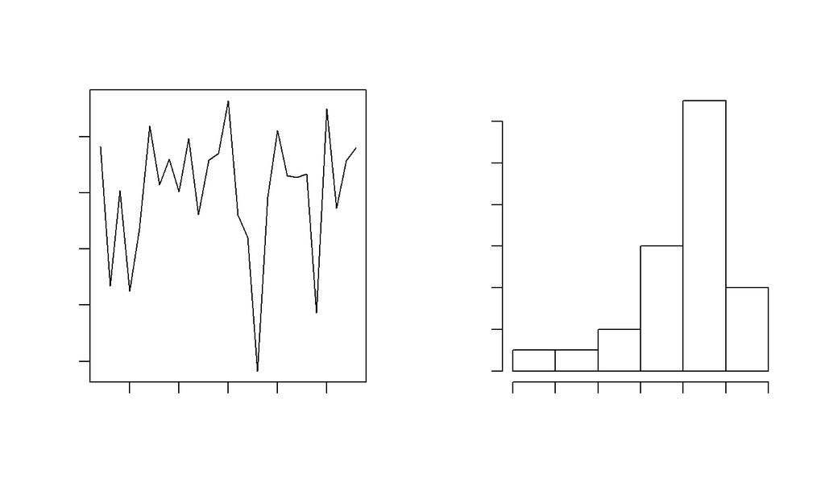

## Testing

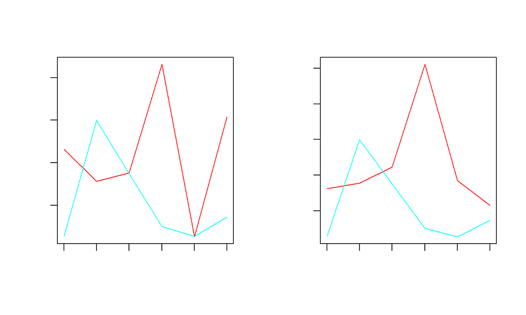

## Residuals

-Linear Model: RMSE = 4.17%, Total = 13.54 -Random Forest: RMSE + 5.86, Total = 14.66

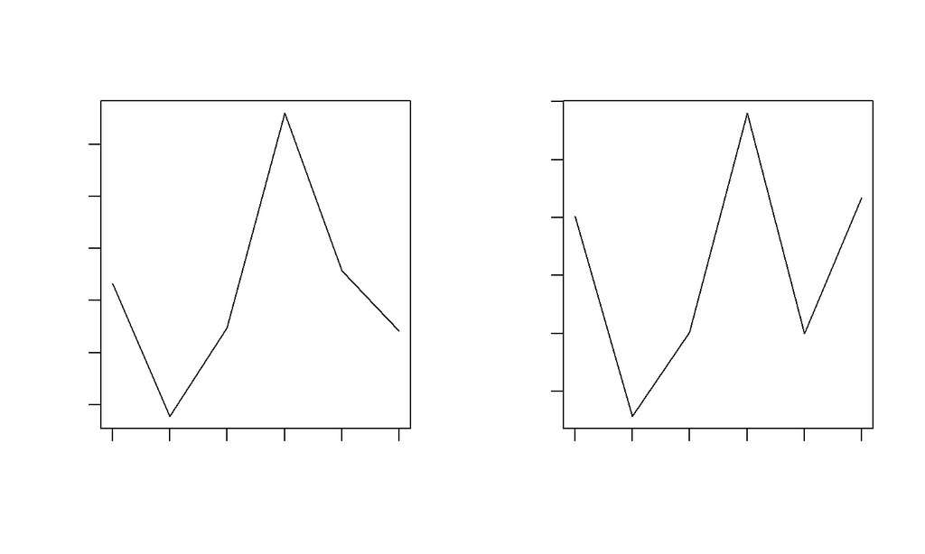